# Final Data Analysis

RL

2024-12-11

# 1 Introduction

Family involvement in schools plays a pivotal role in addressing the developmental and educational needs of students, particularly in organizing support systems tailored to these needs. Understanding the underlying constructs that shape educational processes is critical for evaluating how effectively schools allocate and deliver support to students with diverse needs (Epstein, 2010). For example, family involvement has long been recognized as a key factor in improving student outcomes, including higher academic achievement (e.g., Patall et al., 2008; Hill & Tyson, 2009; Jeynes, 2012), better grade-point averages (e.g., Camarero-Figuerola et al., 2020; Dotterer & Wehrspann, 2016), and reduced dropout rates (e.g., DeWitt et al., 2013; Ziomek-Daigle, 2010). Importantly, the positive effects of family involvement extend beyond academic performance, contributing to better behavioral regulation (e.g., Pears et al., 2015) and enhanced social skills (e.g., Van Voorhis et al., 2013). These benefits are evident across diverse student groups, regardless of variations in ability, race and ethnicity, socioeconomic status, or grade level (Driessen et al., 2005; Hill & Tyson, 2009; Benner et al., 2016; Jeynes, 2012).

Epstein’s (1987) framework on family involvement categorizes engagement into four key types: caregiver obligation, school-home communication, school engagement, and home-based learning activities. However, while comprehensive, Epstein’s framework does not fully capture the distinct needs of students requiring varied levels of support, including those with disabilities. Students with disabilities often necessitate additional layers of engagement, such as specialized family involvement and collaboration frameworks mandated by the Individuals with Disabilities Education Act (IDEA, 2004). Recognizing these nuanced needs, Haines and colleagues (2017) introduced the Sunshine Model, which emphasizes family-professional partnerships over traditional involvement paradigms. This model incorporates seven core principles—communication, respect, professional competence, commitment, equality, advocacy, and trust—aimed at fostering effective partnerships and addressing the needs of diverse student populations, including those with disabilities.

The Sunshine Model’s emphasis on family-professional partnerships aligns with the evolving needs of modern educational systems, particularly frameworks like Multi-Tiered Systems of Support (MTSS). MTSS organizes students into tiers based on their support needs (Tier 1: minimal for mainstream students, Tier 2: targeted for at-risk students, and Tier 3: intensive for referring students to special education), requiring schools to assess not just student outcomes but the partnerships and demographic factors that influence placement into these tiers. While Epstein’s framework provides valuable insights, its limited overlap with the Sunshine Model (primarily in communication) highlights a need for evidence-based models that address the multidimensional relationship between family-professional partnerships and student support needs. This study bridges this gap by exploring how family-professional partnerships and other key factors (i.e., demographic and student learning characteristics) predict student placement in MTSS tiers and identifying the clusters that reflect these levels of support.

Research Questions:

1. How well do clusters derived from data-driven dimensions reflect student types based on their support needs (MTSS tiers 1, 2, or 3) in terms of demographic, student-level, and family-professional partnership factors?
2. How accurate are clusters derived from data-driven dimensions in predicting student types based on their support needs (MTSS tiers 1, 2, or 3)?

# 2 Data

```r
# Load the dataset
pfi_data <- read_csv("pfi_data.csv")

# Inspect the structure of the dataset
glimpse(pfi_data[, c(1:10, (ncol(pfi_data)-9):ncol(pfi_data))])
```

```
## Rows: 16,446
## Columns: 20
## $ BASMID    <dbl> 2.0191e+10, 2.0191e+10, 2.0191e+10, 2.0191e+10, 2.0191e+10, …
## $ ALLGRADEX <dbl> 12, 4, 11, 6, 9, 6, 9, 8, 5, 9, 2, 15, 12, 6, 14, 6, 9, 2, 1…
## $ EDCPUB    <dbl> 1, 1, 2, 1, 1, 1, 2, 1, 1, 1, 1, 1, 1, 1, 1, 1, 1, 2, 1, 1, …
## $ EDCCAT    <dbl> 2, 2, 2, 2, 2, 2, 2, 2, 2, 2, 2, 2, 2, 2, 2, 2, 2, 2, 2, 2, …
## $ EDCREL    <dbl> 2, 2, 1, 2, 2, 2, 2, 2, 2, 2, 2, 2, 2, 2, 2, 2, 2, 2, 2, 2, …
## $ EDCPRI    <dbl> 2, 2, 2, 2, 2, 2, 2, 2, 2, 2, 2, 2, 2, 2, 2, 2, 2, 1, 2, 2, …
## $ EDCINTK12 <dbl> 2, 2, 2, 2, 2, 2, 2, 2, 2, 2, 2, 2, 2, 2, 2, 2, 2, 2, 2, 2, …
## $ EDCINTCOL <dbl> 2, 2, 2, 2, 2, 2, 2, 2, 2, 2, 2, 2, 2, 2, 2, 2, 2, 2, 2, 2, …
## $ EDCCOL    <dbl> 2, 2, 2, 2, 2, 2, 2, 2, 2, 2, 2, 2, 2, 2, 2, 2, 2, 2, 1, 2, …
## $ EDCHSFL   <dbl> 2, 2, 2, 2, 2, 2, 1, 2, 2, 2, 2, 2, 2, 2, 2, 2, 2, 2, 2, 2, …
## $ CHSEX3    <dbl> -1, 1, -1, -1, -1, -1, -1, -1, -1, -1, -9, -1, -1, -1, -1, -…
## $ CHSEX4    <dbl> -1, 1, -1, -1, -1, -1, -1, -1, -1, -1, -9, -1, -1, -1, -1, -…
## $ CHENRL1   <dbl> 3, 2, 2, 2, 2, -1, 1, 2, 2, 2, -9, 2, 2, -1, 2, -1, 2, 2, -1…
## $ CHENRL2   <dbl> -1, 2, -1, -1, -1, -1, -1, 2, -1, -1, -9, 2, -1, -1, 2, -1, …
## $ CHENRL3   <dbl> -1, 2, -1, -1, -1, -1, -1, -1, -1, -1, -9, -1, -1, -1, -1, -…
## $ CHENRL4   <dbl> -1, 2, -1, -1, -1, -1, -1, -1, -1, -1, -9, -1, -1, -1, -1, -…
## $ CHGRD1    <dbl> -9, 15, 4, 7, 10, -1, 9, 3, 2, 10, -9, 6, 9, -1, 2, -1, 5, 6…
## $ CHGRD2    <dbl> -1, 13, -1, -1, -1, -1, -1, 14, -1, -1, -9, 12, -1, -1, 11, …
## $ CHGRD3    <dbl> -1, -9, -1, -1, -1, -1, -1, -1, -1, -1, -9, -1, -1, -1, -1, …
## $ CHGRD4    <dbl> -1, -9, -1, -1, -1, -1, -1, -1, -1, -1, -9, -1, -1, -1, -1, …
```

```r
# Calculate Demographic Characteristics
options(digits = 4) #set outputs limited to 3 decimal places
options(scipen = 999) #disable scientific notation

## Means and SDs
summary_stats <- c(mean_cage = mean(pfi_data$AGE2018), #child's age
                   sd_cage = sd(pfi_data$AGE2018),
                   mean_hht = mean(pfi_data$HHTOTALXX), #total household members
                   sd_hht = sd(pfi_data$HHTOTALXX))
summary_stats
```

```
## mean_cage   sd_cage  mean_hht    sd_hht
##    12.058     3.840     4.070     1.254
```

```r
## Recoding Categorical Variables
pfi_data <- pfi_data %>%
  mutate(S19TYPE = recode(S19TYPE, '-9' = NA_character_, '-1' = "Homeschool",
                          '1' = "Catholic", '2' = "Religious", '3' = "Nonsec",
                          '4' = "Public")) %>%
  mutate(ALLGRADEX = recode(ALLGRADEX, '2' = "G0K", '3' = "G0K", '4' = "G1",
                            '5' = "G2", '6' = "G3", '7' = "G4", '8' = "G5",
                            '9' = "G6", '10' = "G7", '11' = "G8", '12' = "G9",
                            '13' = "G510", '14' = "G11", '15' = "G12")) %>%
  mutate(CSEX2 = recode(CSEX, '1' = "Male", '2' = "Female")) %>%
  mutate(RACEETH = factor(recode(RACEETH, '1' = "White", '2' = "Black",
                                 '3' = "Hispanic", '4' = "Asian",
                                 '5' = "Other"))) %>%
  mutate(RELATION = recode(RELATION, '1' = "Mother", '2' = "Father",
                           '3' = "Aunt", '4' = "Uncle", '5' = "Grandmother",
                           '6' = "Grandfather", '7' = "Other", '8' = "Other",
                           '9' = "Sibling", '10' = "Other", '11' = "Other")) %>%
  mutate(PARGRADEX2 = recode(PARGRADEX, '1' = "E1Below_HS", '2' = "E2HS_Dip",
                             '3' = "E3Voc", '4' = "E4College", '5' = "E5Grad")) %>%
  mutate(TTLHHINC2 = recode(TTLHHINC, '1' = "K010", '2' = "K020", '3' = "K030",
                            '4' = "K040", '5' = "K050", '6' = "K060",
                            '7' = "K075", '8' = "K100", '9' = "K150",
                            '10' = "K200", '11' = "K250", '12' = "K999"))

## Distributions by percent
prop.table(table(pfi_data$S19TYPE)) * 100 #school type
```

```
##
##   Catholic Homeschool     Nonsec     Public  Religious
##      3.755      2.801      2.250     87.518      3.675
```

```r
prop.table(table(pfi_data$ALLGRADEX)) * 100 #grade level
```

```
##
##    G0K     G1    G11    G12     G2     G3     G4     G5   G510     G6     G7
##  6.087  6.087  9.905 10.987  6.020  6.391  6.348  6.950  9.698  7.363  7.692
##     G8     G9
##  8.124  8.349
```

```r
prop.table(table(pfi_data$CSEX2)) * 100 #child sex
```

```
##
## Female   Male
##  48.18  51.82
```

```r
prop.table(table(pfi_data$RACEETH)) * 100 #child's race
```

```
##
##    Asian    Black Hispanic    Other    White
##    6.926    9.516   20.583    6.731   56.245
```

```r
prop.table(table(pfi_data$RELATION)) * 100 #respondent's relation
```

```
##
##        Aunt      Father Grandfather Grandmother      Mother       Other
##      0.7601     30.3721      1.5992      5.1259     59.5646      1.2100
##     Sibling       Uncle
##      1.1067      0.2615
```

```r
prop.table(table(pfi_data$PARGRADEX2)) * 100 #respondent's education
```

```
##
## E1Below_HS   E2HS_Dip      E3Voc  E4College     E5Grad
##      4.968     11.662     28.043     28.007     27.320
```

```r
prop.table(table(pfi_data$TTLHHINC2)) * 100 #household income
```

```
##
##   K010   K020   K030   K040   K050   K060   K075   K100   K150   K200   K250
##  4.025  5.156  7.005  7.272  6.622  6.366  8.750 14.125 18.272  9.765  4.603
##   K999
##  8.038
```

## 2.1 Variables

### 2.1.1 Demographic Factors

RACEETH. For this item, parents were asked to identify their race and ethnicity. Response options include: (1) White, non-Hispanic; (2) Black, non-Hispanic; (3) Hispanic; (4) Asian or Pacific Islander; and (5) All other races and multiple races.

CSEX. For this item, parents were asked the question: “*What is this child’s sex?*” Response options included: (1) Male and (2) Female.

HHTOTALXX. For this item, parents were asked the question: “*Including children, how many people live in this household?*” and were able to input a numeric value.

TTLHHINC. For this item, parents were asked the question: “*Which category best fits the total income of all persons in your household over the past 12 months?*” Response options include: (1) $0 to $10,000; (2) $10,001 to $20,000; (3) $20,001 to $30,000; (4) $30,001 to $40,000; (5) $40,001 to $50,000; (6) $50,001 to $60,000; (7) $60,001 to $75,000; (8) $75,001 to $100,000; (9) $100,001 to $150,000; (10) $150,001 to $200,000; (11) $200,001 to $250,000; and (12) $250,001 or more.

PARGRADEX. For this item, parents were asked the question: “*What is the highest grade or level of school that this parent or guardian completed?*” Response options include: (1) Less than high school credential; (2) High school graduate or equivalent; (3) Vocational/technical education after high school or some college; (4) College graduate; and (5) Graduate or professional school.

### 2.1.2 Student-Level Factors

CENGLPRG. For this item, parents were asked the question: “*Is this child currently enrolled in English as a second language, bilingual education, or an English immersion program?*” Response options included: (-1) Valid Skip; (1) Yes; and (2) No.

DSBLTY. For this item, parents were asked to indicate if their child currently has disability. Response options included: (1) Currently has a disability; and (2) Does not currently have a disability.

HDIEPX. For this item, parents were asked the question: “*Is this child receiving any services through an Individualized Education Program (IEP) or services plan?*” Response options included: (-1) Valid Skip; (1) Yes; and (2) No.

SEGRADES. For this item, parents were asked the question: “*Please tell us about this child’s grades during this school year. Overall, across all subjects, what grades does this child get?*” Response options included: (-1) Valid Skip; (1) Mostly A’s; (2) Mostly B’s; (3) Mostly C’s; (4) Mostly D’s; and (5) School does not give these grades.

SEGRADEQ. For this item, parents were asked the question: “*How would you describe his or her work at school?*” Response options included: (-1) Valid Skip; (1) Excellent; (2) Above average; (3) Average; (4) Below average; and (5) Failing.

SEABSNT. For this item, parents were asked the question: “*Since the beginning of this school year, how many days has this child been absent from school?*” Response options included: (-1) Valid Skip; (1) 0 to 5 days; (2) 6 to 10 days; (3) 11 to 20 days; and (4) More than 20 days.

*For the next few items, parents were asked and were able to input numeric values for the question: “Since the beginning of this school year, how many times have any of this child’s teachers or school staff contacted your household about:”*

SESCHWRK. Problems this child is having with school work?  
SEGWORK. Very good school work?  
SEBEHAVX. Behavior problems this child is having in school?  
SEGBEHAV. Very good behavior?

*For the next few items, parents were asked: “Has this child ever had the following experiences?” Response options included: (-1) Valid Skip; (1) Yes; and (2) No.*

SESUSOUT. An out-of-school suspension.  
SESUSPIN. An in-school suspension not counting detentions.  
SEEXPEL. Been expelled from school.

### 2.1.3 Family-Professional Partnership Factors

FHCHECKX. For this item, parents were asked the question: “*How often does any adult in your household check to see that this child’s homework is done?*” Response options included: (-1) Valid Skip; (1) Never; (2) Rarely; (3) Sometimes; and (4) Always.

FHHELP. For this item, parents were asked the question: “*During this school year, about how many days in an average week does anyone in your household help this child with his or her homework?*” Response options included: (-1) Valid Skip; (1) Less than once a week; (2) 1 to 2 days a week; (3) 3 to 4 days a week; (4) 5 or more days a week; and (5) Never.

FSFREQ. For this item, parents were asked the question: “*During this school year, how many times has any adult in the household gone to meetings or participated in activities at this child’s school?*” and were able to input a numeric value.

*For the next few items, parents were asked: “How well has this child’s school been doing the following things during this school year?” Response options included: (-1) Valid Skip; (1) Very well; (2) Just okay; (3) Not very well; and (4) Does not do it at all.*

FSSPPERF. Letting you know how this child is doing in school between report cards.  
FSSPHW. Providing information about how to help this child with homework.  
FSSPCOUR. Providing information about why this child is placed in particular groups or classes.  
FSSPROLE. Providing information on your expected role at this child’s school.

*For the next few items, parents were asked: “How satisfied or dissatisfied are you with each of the following:” Response options included: (-1) Valid Skip; (1) Very satisfied; (2) Somewhat satisfied; (3) Somewhat dissatisfied; and (4) Very dissatisfied.*

FCSCHOOL. The school this child attends this year?  
FCTEACHR. The teachers this child has this year?  
FCSTDS. The academic standards of the school?  
FCORDER. The order and discipline at the school?  
FCSUPPRT. The way that school staff interacts with parents?

*For the next few items, parents were asked: “Since the beginning of this school year, has any adult in this child’s household done any of the following things at this child’s school?” Response options included: (-1) Valid Skip; (1) Yes; and (2) No.*

FSSPORTX. Attended a school or class event, such as a play, dance, sports event, or science fair.  
FSVOL. Served as a volunteer in this child’s classroom or elsewhere in the school.  
FSMTNG. Attended a general school meeting, for example, an open house, or a back-to-school night.  
FSPTMTNG. Attended a meeting of the parent-teacher organization or association.  
FSATCNFN. Gone to a regularly scheduled parent-teacher conference with this child’s teacher.  
FSFUNDRS. Participated in fundraising for the school.  
FSCOMMTE. Served on a school committee.

# 3 Data Wrangling

The data wrangling process involved selecting relevant variables across categories such as demographics, student-level, and family-professional partnership factors. Variables indicating skipped responses (-1) were recoded to standardize “no” responses, and rows containing any skipped data were removed. Ordinal variables were re-coded to ensure higher values indicated better outcomes, while dichotomous variables were re-coded to binary format (0 and 1). Specific adjustments were made to variables (i.e., academic performance) to align with consistent scales. The cleaned dataset was checked for structure and integrity to ensure it was ready for further analysis.

```r
# Select only relevant variables
vars <- c("RACEETH", "CSEX", "HHTOTALXX", "TTLHHINC", "PARGRADEX", #demographic
          "DSBLTY", "CENGLPRG", "HDIEPX", #student learning needs
          "SESCHWRK", "SEGWORK", "SEGRADES", "SEGRADEQ", #student academics
          "SEBEHAVX", "SEGBEHAV", "SEABSNT", "SESUSOUT",
          "SESUSPIN", "SEEXPEL", #student behavior
          "FSNOTESX", "FSMEMO", "FSPHONCHX", "FSSPPERF",
          "FSSPHW", "FSSPCOUR", "FSSPROLE", #fpp communication
          "FCSCHOOL", "FCTEACHR", "FCSTDS", "FCORDER",
          "FCSUPPRT", #fpp satisfaction
          "FSATCNFN", "FSCOUNSLR",
          "FHCHECKX", "FHHELP", #fpp educational involvement
          "FSSPORTX", "FSVOL", "FSMTNG", "FSPTMTNG",
          "FSFUNDRS", "FSCOMMTE", "FSFREQ" #fpp school involvement
          )

# Subset the data to include only relevant variables
pfi_data <- pfi_data %>%
  select(all_of(vars)) %>%
  mutate(CENGLPRG = recode(CENGLPRG, `-1` = 2)) %>%
  #recode branch items so skip becomes no
  mutate(HDIEPX = recode(HDIEPX, `-1` = 2)) %>%
  #recode branch items so skip becomes no
  filter(if_all(everything(), ~ . != -1))
  #remove rows where any selected variable is -1 or Valid Skips

# Re-code variables
recode_ord <- c("SEGRADES", "SEGRADEQ", "FSSPPERF", "FSSPHW", "FSSPCOUR",
                "FSSPROLE", "FCSCHOOL", "FCTEACHR", "FCSTDS", "FCORDER",
                "FCSUPPRT") #ordinal variables

recode_dic <- c("CSEX", "DSBLTY", "CENGLPRG", "HDIEPX", "SESUSOUT",
                "SESUSPIN", "SEEXPEL", "FSNOTESX", "FSMEMO", "FSPHONCHX",
                "FSATCNFN", "FSCOUNSLR", "FSSPORTX", "FSVOL", "FSMTNG",
                "FSPTMTNG", "FSFUNDRS", "FSCOMMTE") #dichotomous

pfi_data_clean <- pfi_data %>%
  mutate(across(all_of(recode_ord),
                ~ recode(., `1` = 4, `2` = 3, `3` = 2, `4` = 1))) %>%
                #higher = better
  mutate(across(all_of(recode_dic), ~ recode(., `2` = 0))) %>% #no's becomes 0s
  mutate(SEGRADES = recode(SEGRADEQ, `5` = 0)) %>% #failing becomes 0s
  mutate(FHHELP = recode(FHHELP, `5` = 0)) #never becomes 0s

#Check Data
glimpse(pfi_data_clean)
```

```
## Rows: 14,677
## Columns: 41
## $ RACEETH   <fct> Asian, Hispanic, Black, Hispanic, Other, White, Hispanic, Wh…
## $ CSEX      <dbl> 0, 1, 1, 1, 1, 0, 0, 0, 1, 1, 0, 1, 1, 1, 0, 1, 1, 0, 0, 0, …
## $ HHTOTALXX <dbl> 4, 9, 3, 3, 4, 3, 5, 6, 4, 3, 5, 4, 3, 5, 4, 5, 2, 3, 3, 4, …
## $ TTLHHINC  <dbl> 8, 5, 3, 2, 10, 10, 3, 12, 11, 7, 3, 10, 8, 5, 8, 8, 7, 7, 8…
## $ PARGRADEX <dbl> 3, 3, 5, 2, 5, 5, 3, 4, 5, 3, 4, 5, 4, 2, 3, 3, 4, 4, 4, 5, …
## $ DSBLTY    <dbl> 0, 0, 0, 0, 0, 0, 1, 1, 0, 0, 1, 1, 1, 0, 0, 1, 0, 0, 0, 0, …
## $ CENGLPRG  <dbl> 0, 1, 0, 0, 0, 0, 0, 0, 0, 0, 0, 0, 0, 0, 0, 0, 0, 0, 0, 0, …
## $ HDIEPX    <dbl> 0, 0, 0, 0, 0, 0, 0, 1, 0, 0, 1, 1, 1, 0, 0, 1, 0, 0, 0, 0, …
## $ SESCHWRK  <dbl> 0, 2, 1, 0, 0, 0, 1, 0, 0, 0, 1, 1, 1, 0, 0, 0, 0, 0, 1, 0, …
## $ SEGWORK   <dbl> 0, 0, 3, 2, 0, 10, 0, 2, 0, 0, 1, 1, 0, 0, 0, 0, 0, 99, 0, 1…
## $ SEGRADES  <dbl> 4, 2, 1, 4, 4, 4, 3, 2, 4, 2, 2, 3, 1, 3, 3, 3, 4, 4, 2, 4, …
## $ SEGRADEQ  <dbl> 4, 2, 1, 4, 4, 4, 3, 2, 4, 2, 2, 3, 1, 3, 3, 3, 4, 4, 2, 4, …
## $ SEBEHAVX  <dbl> 0, 0, 10, 0, 0, 0, 1, 0, 0, 0, 0, 0, 10, 0, 0, 0, 0, 0, 1, 0…
```

[output cut: 28 more lines]

# 4 Multicollinearity Check

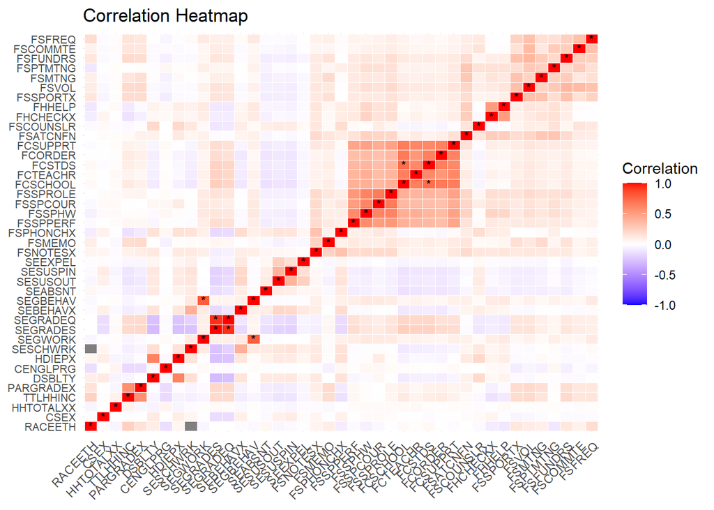

```r
# Correlations
cor_matrix <- hetcor(as.data.frame(pfi_data_clean))$correlations

# Reshape correlation matrix into long format
cor_matrix_long <- melt(cor_matrix)

# Add a column for significance
cor_matrix_long$Significance <- ifelse(abs(cor_matrix_long$value) > 0.7, "*", "")

# Plot the heatmap
cor_heatmap <- ggplot(cor_matrix_long, aes(x = Var1, y = Var2, fill = value)) +
  geom_tile(color = "white") +
  scale_fill_gradient2(low = "blue", high = "red", mid = "white",
                       midpoint = 0, limit = c(-1, 1), space = "Lab") +
  geom_text(aes(label = Significance), color = "black", size = 3) +
  theme_minimal() +
  theme(axis.text.x = element_text(angle = 45, hjust = 1),
        axis.text.y = element_text(size = 8),
        axis.title = element_blank()) +
  labs(title = "Correlation Heatmap", fill = "Correlation")
cor_heatmap
```

```r
# Remove highly correlated
pfi_data_clean <- pfi_data_clean %>%
  select(-SEGRADES, -SEGWORK, -FCSTDS)
```

# 5 Dimension Reduction

Exploratory Graph Analysis (EGA) utilizes network-based methodologies to explore data structures by identifying clusters of highly correlated variables, which can be indicative of underlying components (Golino & Epskamp, 2017). In conducting EGA, employing techniques like regularization and ensuring generalizability are crucial steps to derive reliable and meaningful insights from complex datasets. Regularization, through Graphical LASSO (GLASSO), is vital for managing the dimensionality and sparsity of the network models generated during EGA (Epskamp & Fried, 2018). This method allows the controlling for overfitting by penalizing the inclusion of less significant connections, thus helping to uncover the most influential relationships in the data. Generalizability can be ensured through bootstrapping, a technique that assesses the stability and reliability of the network by repeatedly sampling the data with replacement (Christensen & Golino, 2021b).

Specifically, the current process of dimension reduction was conducted through a three-step process. Utilizing the EGAnet (Golino & Christensen, 2024a) package in R, Unique Variable Analysis (UVA) was first applied to the data to prevent local dependence between the variables and reduce redundancy (Christensen et al., 2023a). For UVA, the default method of retaining the variable with the lowest maximum weighted topological overlap (wTO) to all other variables was utilized. Next, EGA with optimal model fit (vs. standard EGA) was conducted using the default network estimation method of GLASSO because of the polytomous nature and number of variables in the dataset (Jamison et al., 2021). The community detection algorithm, ‘*leiden*’, was utilized due to the unequal number of variables that was expected per theoretical constructs (Christensen et al., 2023b). Lastly, bootstrapping was conducted on the best fitting model by specifying the ‘bootEGA()’ function alongside ‘EGA.fit()’ which performs EGA across the default (500) replicated bootstrap samples, with the aggregated bootstrapped model compared to the empirical model based on the original data.

To compare between the EGAs resulting from the community detection algorithms, model fit was assessed via the Total Entropy Fit Index (TEFI) which has been validated in simulation studies to be as accurate or more accurate than traditional fit indices (e.g., CFI, RMSEA, SRMR; Golino et al., 2020). Network loadings, akin to factor loadings in Principal Component Analysis (PCA), were calculated to determine how adequately the variables align with their suggested dimension. Acceptable cutoff values were determined based on the commonly proposed value of .4 for factor loading in PCA, which is analogous to a value of .2 in terms of network loading (Christensen et al., 2024). Stability values for the bootstrapped models were evaluated on proposed guideline values (>.75; Christensen & Golino, 2021b).

```r
# Perform UVA
pfi_uva <- UVA(pfi_data_clean)
pfi_uva
```

```
## Variable pairs with wTO > 0.30 (large-to-very large redundancy)
##
##    node_i    node_j   wto
##    DSBLTY    HDIEPX 0.778
##  FHCHECKX    FHHELP 0.434
##  FCSCHOOL   FCORDER 0.342
##  TTLHHINC PARGRADEX 0.329
##  FSSPCOUR  FSSPROLE 0.303
##
## ----
##
## Variable pairs with wTO > 0.25 (moderate-to-large redundancy)
##
##    node_i    node_j   wto
##  SESUSOUT   SEEXPEL 0.298
##  FCSCHOOL  FCTEACHR 0.292
##  SESUSOUT  SESUSPIN 0.290
##  FSCOMMTE    FSFREQ 0.265
##  SEBEHAVX   SEEXPEL 0.264
##   FCORDER  FCSUPPRT 0.262
##  FSNOTESX FSPHONCHX 0.258
##
## ----
##
## Variable pairs with wTO > 0.20 (small-to-moderate redundancy)
##
##    node_i   node_j   wto
##  FSSPPERF   FSSPHW 0.250
##     FSVOL FSCOMMTE 0.234
##    FSSPHW FSSPCOUR 0.232
##  FCSCHOOL FCSUPPRT 0.230
##    FSSPHW FSSPROLE 0.211
##  FCTEACHR FCSUPPRT 0.211
##   RACEETH CENGLPRG 0.207
##  FSNOTESX   FSMEMO 0.203
##  FSSPORTX    FSVOL 0.200
```

```r
# Estimate EGA
pfi_fit <- EGA.fit(data = pfi_uva$reduced_data, algorithm = "leiden")
```

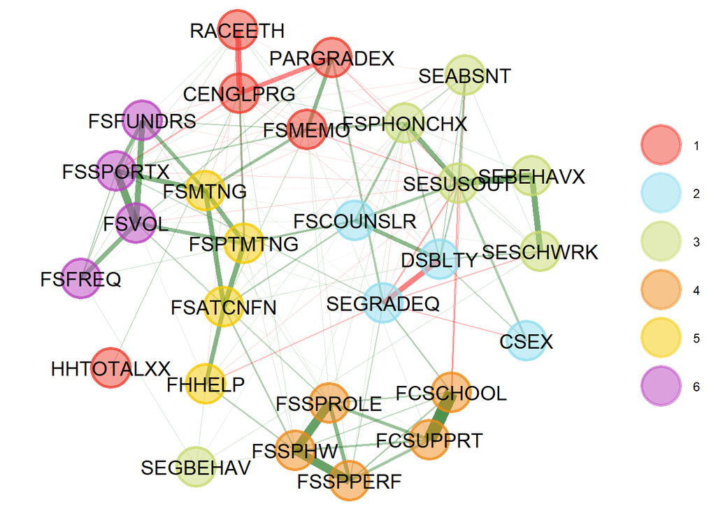

```r
summary(pfi_fit)
```

```
## Model: GLASSO (EBIC with gamma = 0.5)
## Correlations: auto
## Lambda: 0.0786861205901863 (n = 100, ratio = 0.1)
##
## Number of nodes: 28
## Number of edges: 136
## Edge density: 0.360
##
## Non-zero edge weights:
##      M    SD    Min   Max
##  0.052 0.108 -0.262 0.561
##
## ----
##
## Algorithm:  Leiden with Modularity (Resolution = 1.85)
##
## Number of communities:  6
##
##   RACEETH      CSEX HHTOTALXX PARGRADEX    DSBLTY  CENGLPRG  SESCHWRK  SEGRADEQ
##         1         2         1         1         2         1         3         2
##  SEBEHAVX  SEGBEHAV   SEABSNT  SESUSOUT    FSMEMO FSPHONCHX  FSSPPERF    FSSPHW
##         3         3         3         3         1         3         4         4
##  FSSPROLE  FCSCHOOL  FCSUPPRT  FSATCNFN FSCOUNSLR    FHHELP  FSSPORTX     FSVOL
##         4         4         4         5         2         5         6         6
##    FSMTNG  FSPTMTNG  FSFUNDRS    FSFREQ
##         5         5         6         6
##
##
## ----
##
## TEFI: -29.899
```

```r
# Compute Node Strength
pfi_loadings <- net.loads(pfi_fit, loading.method = "experimental")
summary(pfi_loadings)
```

```
## Loading Method: Experimental
##
##           1      2      3     4     5     6
## PARGRADEX  0.374
## RACEETH    0.279
## FSMEMO     0.235                    0.124
## HHTOTALXX
## CENGLPRG  -0.527
## DSBLTY            0.529 0.194
## FSCOUNSLR         0.208 0.166       0.118
## CSEX              0.134
## SEGRADEQ         -0.332 -0.13
## SESUSOUT          0.309  0.53
## SEBEHAVX                0.491
## SESCHWRK          0.122 0.331
## FSPHONCHX         0.182 0.268
## SEABSNT                 0.138
## SEGBEHAV
## FCSUPPRT                      0.566
## FSSPHW                        0.554 0.114
## FSSPROLE                      0.484
## FCSCHOOL                      0.469
## FSSPPERF                      0.468
## FSATCNFN                            0.601
## FSPTMTNG   -0.11                    0.389 0.103
## FSMTNG     0.167                    0.387 0.255
## FHHELP                              0.187
## FSVOL                               0.165 0.624
## FSSPORTX   0.147                    0.149 0.451
## FSFUNDRS                            0.113 0.397
## FSFREQ                                    0.255
## Standardized loadings >= |0.10| are displayed. To change this 'minimum', use `print(net.loads_object, minimum = 0.10)`
```

```r
#network loading of .2 would generally equate to .4 in terms of PCA metrics

# Remove low loading variables
pfi_data_clean_load <- pfi_data_clean %>%
  select(-HHTOTALXX, -CSEX, -SEGBEHAV, -SEABSNT, -FHHELP)

# Redo UVA
pfi_uva <- UVA(pfi_data_clean_load)
pfi_uva
```

```
## Variable pairs with wTO > 0.30 (large-to-very large redundancy)
##
##    node_i    node_j   wto
##    DSBLTY    HDIEPX 0.798
##  FCSCHOOL   FCORDER 0.344
##  TTLHHINC PARGRADEX 0.329
##  SESUSOUT  SESUSPIN 0.314
##  FSSPCOUR  FSSPROLE 0.303
##
## ----
##
## Variable pairs with wTO > 0.25 (moderate-to-large redundancy)
##
##    node_i    node_j   wto
##  SESUSOUT   SEEXPEL 0.299
##  FCSCHOOL  FCTEACHR 0.293
##  FSCOMMTE    FSFREQ 0.267
##  FSNOTESX FSPHONCHX 0.264
##  SEBEHAVX   SEEXPEL 0.264
##   FCORDER  FCSUPPRT 0.264
##  FSSPPERF    FSSPHW 0.250
##
## ----
##
## Variable pairs with wTO > 0.20 (small-to-moderate redundancy)
##
##    node_i   node_j   wto
##     FSVOL FSCOMMTE 0.234
##    FSSPHW FSSPCOUR 0.233
##  FCSCHOOL FCSUPPRT 0.230
##  FCTEACHR FCSUPPRT 0.212
##    FSSPHW FSSPROLE 0.211
##   RACEETH CENGLPRG 0.207
##  FSNOTESX   FSMEMO 0.203
##  FSSPORTX    FSVOL 0.202
```

```r
# Redo EGA
pfi_fit <- EGA.fit(data = pfi_uva$reduced_data, algorithm = "leiden")
```

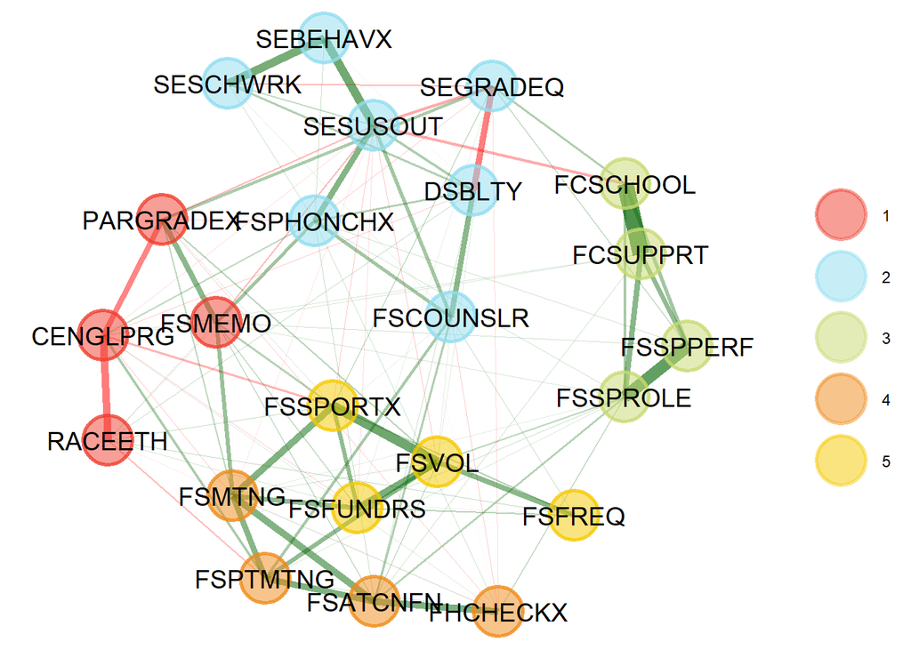

```r
summary(pfi_fit)
```

```
## Model: GLASSO (EBIC with gamma = 0.5)
## Correlations: auto
## Lambda: 0.0786861205901863 (n = 100, ratio = 0.1)
##
## Number of nodes: 23
## Number of edges: 109
## Edge density: 0.431
##
## Non-zero edge weights:
##      M    SD    Min   Max
##  0.058 0.116 -0.263 0.571
##
## ----
##
## Algorithm:  Leiden with Modularity (Resolution = 1)
##
## Number of communities:  5
##
##   RACEETH PARGRADEX    DSBLTY  CENGLPRG  SESCHWRK  SEGRADEQ  SEBEHAVX  SESUSOUT
##         1         1         2         1         2         2         2         2
##    FSMEMO FSPHONCHX  FSSPPERF  FSSPROLE  FCSCHOOL  FCSUPPRT  FSATCNFN FSCOUNSLR
##         1         2         3         3         3         3         4         2
##  FHCHECKX  FSSPORTX     FSVOL    FSMTNG  FSPTMTNG  FSFUNDRS    FSFREQ
##         4         5         5         4         4         5         5
##
##
## ----
##
## TEFI: -23.569
```

```r
# Compute New Node Strength
pfi_loadings <- net.loads(pfi_fit, loading.method = "experimental")
summary(pfi_loadings)
```

```
## Loading Method: Experimental
##
##           1      2      3     4     5
## PARGRADEX   0.39
## RACEETH    0.292
## FSMEMO     0.244              0.121
## CENGLPRG  -0.488
## SESUSOUT          0.562
## DSBLTY            0.435
## SEBEHAVX          0.398
## FSPHONCHX         0.329
## SESCHWRK          0.326
## FSCOUNSLR         0.275
## SEGRADEQ         -0.278
## FCSUPPRT                0.631
## FCSCHOOL                0.528
## FSSPROLE                0.469
## FSSPPERF                0.459
## FSATCNFN                      0.592
## FSPTMTNG  -0.109              0.397 0.103
## FSMTNG     0.165              0.389 0.255
## FHCHECKX                      0.242
## FSVOL                         0.154 0.624
## FSSPORTX   0.143              0.144 0.451
## FSFUNDRS                      0.109 0.397
## FSFREQ                              0.255
## Standardized loadings >= |0.10| are displayed. To change this 'minimum', use `print(net.loads_object, minimum = 0.10)`
```

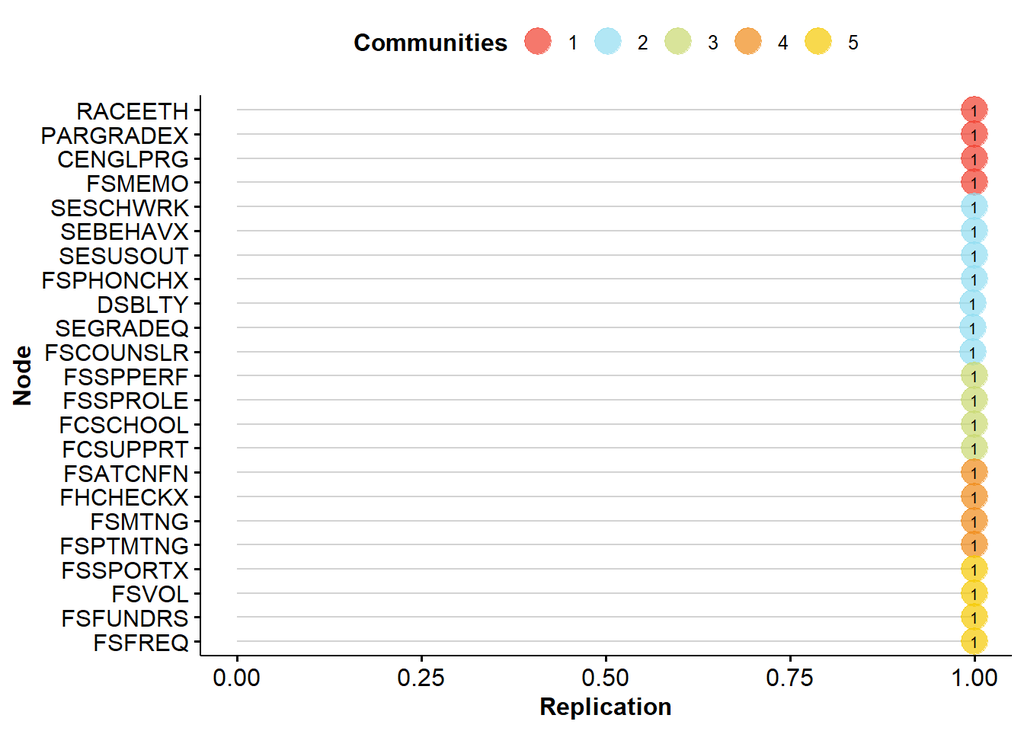

```
## EGA Type: EGA.fit
## Bootstrap Samples: 500 (Parametric)
##
## Proportion Replicated in Dimensions:
##
##   RACEETH PARGRADEX    DSBLTY  CENGLPRG  SESCHWRK  SEGRADEQ  SEBEHAVX  SESUSOUT
##     1.000     1.000     0.998     1.000     1.000     0.998     1.000     1.000
##    FSMEMO FSPHONCHX  FSSPPERF  FSSPROLE  FCSCHOOL  FCSUPPRT  FSATCNFN FSCOUNSLR
##     1.000     1.000     1.000     1.000     1.000     1.000     1.000     0.998
##  FHCHECKX  FSSPORTX     FSVOL    FSMTNG  FSPTMTNG  FSFUNDRS    FSFREQ
##     1.000     1.000     1.000     1.000     1.000     1.000     1.000
##
## ----
##
## Structural Consistency:
##
##     1     2     3     4     5
## 1.000 0.998 1.000 1.000 1.000
```

```r
# Bootstrap to check stability
pfi_fit_boot <- bootEGA(data = pfi_uva$reduced_data, algorithm = "leiden",
                        EGA.type = "EGA.fit", seed = 123,
                        plot.itemStability = FALSE)
dimensionStability(pfi_fit_boot)
```

```r
# Get Network (factor) Scores
ega_net_scores <- net.scores(data = pfi_uva$reduced_data, pfi_fit,
                             loading.method = "experimental")
```

```r
# Rename columns to be more descriptive
ega_net_scores <- as.data.frame(ega_net_scores$scores$std.scores) %>%
  #these scores are already standardized
  rename(demographic = 1, studentchar = 2, satisfaction = 3,
         eduinvolvement = 4, schoolinv = 5)
```

# 6 Cluster Analysis

K-means clustering was utilized to group students based on their underlying characteristics derived from EGA network scores. This approach allowed for the identification of data-driven clusters that align with the organizational tiers of MTSS. The EGA network scores served as input variables, capturing dimensions relevant to student support needs. A total of three clusters were specified to correspond with the MTSS tiers, and the ‘kmeans’ function was employed to partition the data. To ensure robustness, the clustering was performed with 25 random starts, reducing the likelihood of converging to a local minimum.

For visualization, the clustering results were plotted to display the partitioned data and centroids in a two-dimensional space. This visualization allowed for a clear assessment of cluster separation and determine alignment with the MTSS tier framework.

```r
# Perform K-means clustering
set.seed(123)  # For reproducibility
kmeans_result <- kmeans(ega_net_scores, centers = 3, nstart = 25)
kmeans_result$size
```

```
## [1] 1463 8732 4482
```

```r
kmeans_result$centers
```

```
##   demographic studentchar satisfaction eduinvolvement schoolinv
## 1    -0.10978      3.0860      -0.3699         0.1864   -0.2700
## 2     0.08663     -0.3740       0.9880         0.2942    0.3653
## 3    -0.13293     -0.2787      -1.8041        -0.6340   -0.6236
```

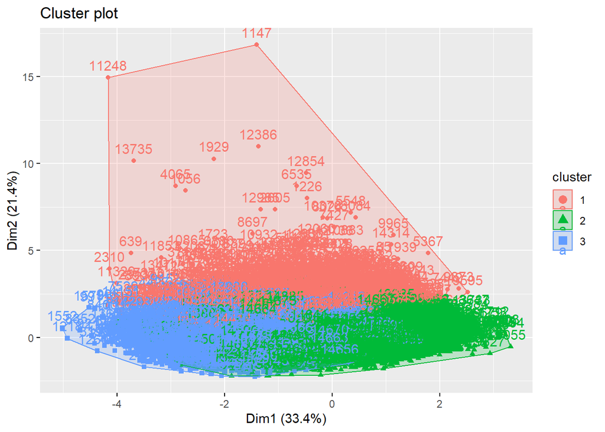

```r
# Visualize the clustering result
fviz_cluster(kmeans_result, data = ega_net_scores)
```

```r
# Adding cluster into dataset
MTSS <- kmeans_result$cluster
pfi_data_final <- cbind(pfi_data_clean, as.data.frame(MTSS))
```

# 7 Regression Analysis

To develop a data-driven model predicting student type according to MTSS tiers, a multinomial regression framework with cross-validation and bidirectional stepwise feature selection was employed. The dataset was split into 70% training and 30% testing subsets. A seed was set for reproducibility, ensuring consistent division of training and test sets across analyses. The reference categories for the outcome variable (MTSS tiers) and the race/ethnicity predictor were redefined to “Cluster B” and “White,” respectively, for interpretability.

The training set was prepared using 10-fold cross-validation. In this method, the model iteratively used 90% of the training data for parameter estimation while holding out 10% for validation, rotating through all subsets to evaluate performance comprehensively. The stepwise feature selection, specified in both forward and backward directions, identified the most predictive variables (dimension components) for the outcome. This automated process dynamically included or excluded predictors to optimize model fit while avoiding overfitting. To evaluate performance, the trained model was then tested on the reserved 30% testing data. Predictions were generated for the test set, allowing for an assessment of the model’s accuracy and generalizability.

```r
# Prepare data
pfi_data_final_sc <- pfi_data_final %>%
  na.omit() %>% #ensure rows with NAs are removed
  mutate(MTSS = as.factor(MTSS)) %>% #change outcome to factor
  mutate(MTSS = recode(MTSS, '2' = "A", '3' = "B", '1' = "C")) %>%
  mutate(MTSS = factor(MTSS, levels = c("A", "B", "C")))%>%
  mutate_at(-c(1, 39), ~(scale(.) %>% as.vector))
  #scale non-categorical variables so mean is zero and values are standardized
  #as.vector ensures columns are vectors

# Set seed for replication purposes
set.seed(1234)

pfi_data_final_sc <- cbind(pfi_data_final_sc, ega_net_scores)

# Set Cluster B as reference for MTSS and White as reference for Race
pfi_data_final_sc$MTSS <- relevel(pfi_data_final_sc$MTSS, ref = "B")
pfi_data_final_sc$RACEETH <- relevel(pfi_data_final_sc$RACEETH, ref = "White")

# Create new variable in tibble for division into training and test sets
pfi_data_final_sc_t_t <- pfi_data_final_sc %>%
  mutate(id = row_number())

# 70% of data as training set
train_set <- pfi_data_final_sc_t_t %>%
  sample_frac(0.70) #selects 70% of observations

# 30% of data test set
test_set  <- anti_join(pfi_data_final_sc_t_t, train_set, by = 'id')
#anti_join, take remaining observations not in train_set

# Remove unnecessary variables
train_set <- train_set[39:44]

test_set <- test_set[39:44]
```

```r
# Select features for training model
model_train_pfi <- train(MTSS ~ .,
                 data = train_set,
                 method="multinom", #multinomial regression
                 stepwise = TRUE, #step-wise
                 direction="both", #both backwards and foward
                 trControl = trainControl(method = "cv", number = 10))
                 #cross validation with 10x/folds
```

```r
# Training Results
summary(model_train_pfi)
```

```
## Call:
## nnet::multinom(formula = .outcome ~ ., data = dat, decay = param$decay,
##     stepwise = TRUE, direction = "both")
##
## Coefficients:
##   (Intercept) demographic studentchar satisfaction eduinvolvement schoolinv
## A       78.67      12.743      -4.692        157.4          51.80     55.57
## C     -156.34       1.568     188.744         81.5          46.02     20.54
##
## Std. Errors:
##   (Intercept) demographic studentchar satisfaction eduinvolvement schoolinv
## A       11.37       1.877      0.8852        22.72          7.499     8.019
## C       22.63       1.345     27.1668        11.75          6.689     3.054
##
## Residual Deviance: 46.34
## AIC: 70.34
```

```r
model_train_pfi$finalModel
```

```
## Call:
## nnet::multinom(formula = .outcome ~ ., data = dat, decay = param$decay,
##     stepwise = TRUE, direction = "both")
##
## Coefficients:
##   (Intercept) demographic studentchar satisfaction eduinvolvement schoolinv
## A       78.67      12.743      -4.692        157.4          51.80     55.57
## C     -156.34       1.568     188.744         81.5          46.02     20.54
##
## Residual Deviance: 46.34
## AIC: 70.34
```

```r
# Extract coefficients and standard errors
coef_matrix <- summary(model_train_pfi$finalModel)$coefficients
se_matrix <- summary(model_train_pfi$finalModel)$standard.errors

# Calculate z-scores and p-values
z_scores <- coef_matrix / se_matrix
p_values <- (1 - pnorm(abs(z_scores), 0, 1)) * 2  # Two-tailed p-values

# Combine values together into dataframe
train_pfi_descrip <- as.data.frame(t(round(coef_matrix, 3))) %>%
  rename_with(~ paste0("Coef_", rownames(coef_matrix)), everything()) %>%
  bind_cols(as.data.frame(t(round(se_matrix, 3))) %>%
              rename_with(~ paste0("SE_", rownames(se_matrix)), everything())) %>%
  bind_cols(as.data.frame(t(round(p_values, 3))) %>%
              rename_with(~ paste0("P_", rownames(p_values)), everything())) %>%
  rownames_to_column("Predictor")

# View the final model descriptive stats
train_pfi_descrip
```

```
##        Predictor  Coef_A   Coef_C   SE_A   SE_C P_A   P_C
## 1    (Intercept)  78.671 -156.343 11.373 22.625   0 0.000
## 2    demographic  12.743    1.568  1.877  1.345   0 0.244
## 3    studentchar  -4.692  188.744  0.885 27.167   0 0.000
## 4   satisfaction 157.416   81.502 22.720 11.749   0 0.000
## 5 eduinvolvement  51.805   46.018  7.499  6.689   0 0.000
## 6      schoolinv  55.567   20.540  8.019  3.054   0 0.000
```

```r
# Evaluate the model performance on the test data
test_predictions <- predict(model_train_pfi, newdata = test_set)
```

# 8 Prediction Performance

The predictive performance of the multinomial logistic regression model was evaluated using a confusion matrix and a mosaic plot. Actual MTSS tier values from the test data and predicted values from the final model were recoded into numeric variables and converted into factors for analysis. The confusion matrix summarized performance metrics, including accuracy, sensitivity, and precision, providing detailed insights into the model’s classification abilities. Visualization was employed via a mosaic plot which compared actual and predicted classifications, with cell size and color indicating agreement and misclassification patterns.

```r
# Add and recode predicted values in tibble
test_set_pred <- test_set %>%
  mutate (predicted = test_predictions) %>% #add in predicted vector
  mutate(act_num = ifelse(MTSS == "A", 1,
         ifelse(MTSS == "B", 2, 3))) %>%  #numeric var for actual MTSS
  mutate(pred_num = ifelse(predicted == "A", 1,
         ifelse(predicted == "B", 2, 3))) %>%  #numeric var for predicted MTSS
  mutate_at(c("act_num", "pred_num"), as.factor) #factor for confusion matrix

# Check the data
glimpse(test_set_pred)
```

```
## Rows: 4,403
## Columns: 9
## $ MTSS           <fct> B, C, A, B, A, A, B, C, A, A, B, A, A, B, A, A, B, B, A…
## $ demographic    <dbl> -3.054615, 0.212064, -0.597331, -0.255089, 0.521815, 0.…
## $ studentchar    <dbl> -0.40100, 4.80975, -0.03475, 0.36594, 1.05059, -0.66342…
## $ satisfaction   <dbl> 0.04504, -6.37366, 1.57393, -0.25878, 1.57393, 1.10802,…
## $ eduinvolvement <dbl> -2.0773, 0.8599, 1.1400, 0.3435, 0.3435, 0.3435, -1.280…
## $ schoolinv      <dbl> -0.80730, 0.81620, 1.16385, -2.04129, -0.04312, 1.19087…
## $ predicted      <fct> B, C, A, B, A, A, B, C, A, A, B, A, A, B, A, A, B, B, A…
## $ act_num        <fct> 2, 3, 1, 2, 1, 1, 2, 3, 1, 1, 2, 1, 1, 2, 1, 1, 2, 2, 1…
## $ pred_num       <fct> 2, 3, 1, 2, 1, 1, 2, 3, 1, 1, 2, 1, 1, 2, 1, 1, 2, 2, 1…
```

```r
table(test_set_pred$act_num)
```

```
##
##    1    2    3
## 2625 1333  445
```

```r
# create confusion matrix using CARET
confusionMatrix(test_set_pred$act_num, test_set_pred$pred_num,
                mode = "everything", #reported stats
                positive="1")
```

```
## Confusion Matrix and Statistics
##
##           Reference
## Prediction    1    2    3
##          1 2621    3    1
##          2    0 1333    0
##          3    0    0  445
##
## Overall Statistics
##
##                Accuracy : 0.999
##                  95% CI : (0.998, 1)
##     No Information Rate : 0.595
##     P-Value [Acc > NIR] : <0.0000000000000002
##
##                   Kappa : 0.998
##
##  Mcnemar's Test P-Value : NA
##
## Statistics by Class:
##
##                      Class: 1 Class: 2 Class: 3
## Sensitivity             1.000    0.998    0.998
## Specificity             0.998    1.000    1.000
## Pos Pred Value          0.998    1.000    1.000
## Neg Pred Value          1.000    0.999    1.000
## Precision               0.998    1.000    1.000
## Recall                  1.000    0.998    0.998
## F1                      0.999    0.999    0.999
## Prevalence              0.595    0.303    0.101
## Detection Rate          0.595    0.303    0.101
## Detection Prevalence    0.596    0.303    0.101
## Balanced Accuracy       0.999    0.999    0.999
```

```r
# Create table with actual and predicted values
mosaic_table <- table(test_set_pred$act_num, test_set_pred$pred_num)
mosaic_table #check table
```

```
##
##        1    2    3
##   1 2621    3    1
##   2    0 1333    0
##   3    0    0  445
```

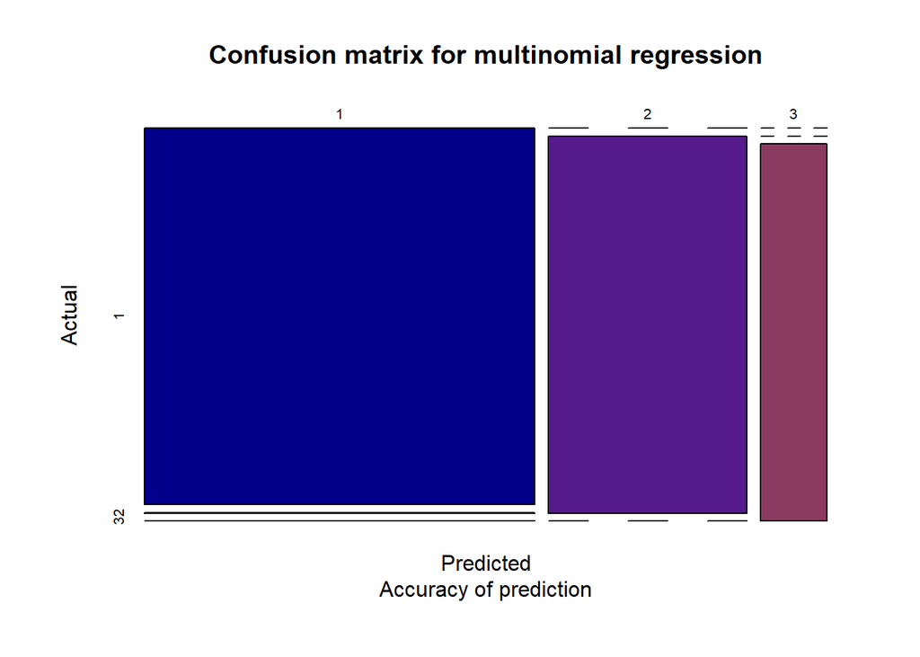

```r
# simple mosaic plot
mosaicplot(mosaic_table,
           main = "Confusion matrix for multinomial regression", #title
           sub = "Accuracy of prediction", #description
           xlab = "Predicted", #x axis label
           ylab = "Actual", #y axis label
           color = c("blue4", "purple4", "hotpink4"),
           border = "black")
```

# 9 Descriptive Statistics

Descriptive statistics of demographic, student-level, and family-professional partnership variables grouped by MTSS tiers in terms of the mean and standard deviation were calculated.

```r
# Recode Cluster into MTSS Tiers
pfi_data_final_sc <- pfi_data_final_sc %>%
  mutate(MTSS = recode(MTSS, 'A' = "T1", 'B' = "T2", 'C' = "T3")) %>%
  mutate(MTSS = factor(MTSS, levels = c("T1", "T2", "T3")))

# Generate descriptive statistics
summary_stats <- pfi_data_final_sc[2:39] %>%
  group_by(MTSS) %>%  # Group by MTSS tiers
  summarise(across(everything(),
                   list(mean = ~ round(mean(. , na.rm = TRUE), 3),
                        sd = ~ round(sd(. , na.rm = TRUE), 3)))) %>%
  pivot_longer(cols = -MTSS,  # Transform variables into a long format
               names_to = c("Variable", ".value"),
               names_sep = "_") %>%
  pivot_wider(names_from = MTSS,
              values_from = c(mean, sd),
              names_glue = "{MTSS}_{.value}") %>%
  ungroup()

# Reorder columns for better structure
summary_stats <- summary_stats %>%
  select(Variable,
         T1_mean, T1_sd,
         T2_mean, T2_sd,
         T3_mean, T3_sd)

# View the output table
summary_stats
```

```
## # A tibble: 37 × 7
##    Variable  T1_mean T1_sd T2_mean T2_sd T3_mean T3_sd
##    <chr>       <dbl> <dbl>   <dbl> <dbl>   <dbl> <dbl>
##  1 CSEX       -0.033 1      -0.043 1       0.327 0.937
##  2 HHTOTALXX   0.022 0.96   -0.005 1.05   -0.116 1.05
##  3 TTLHHINC    0.124 0.979  -0.117 0.985  -0.379 1.03
##  4 PARGRADEX   0.116 0.98   -0.144 1.01   -0.253 0.974
##  5 DSBLTY     -0.143 0.894  -0.095 0.933   1.14  1.07
##  6 CENGLPRG   -0.009 0.976   0.024 1.06   -0.019 0.948
##  7 HDIEPX     -0.113 0.837  -0.117 0.83    1.03  1.60
##  8 SESCHWRK   -0.133 0.316  -0.096 0.412   1.09  2.76
##  9 SEGRADEQ    0.241 0.89   -0.152 0.986  -0.973 0.984
## 10 SEBEHAVX   -0.123 0.3    -0.115 0.329   1.09  2.80
## # ℹ 27 more rows
```

# 10 Example Interpretation of Results

The descriptive results suggest the following insights for students in the at-risk category (Tier 2, the reference group) when evaluating the impact of the following demographic factors:

1. Parent Education Attainment (PARGRADEX)
   - Students whose parents have higher educational attainment are more prevalent in mainstream supports (Tier 1) and may highlight systemic inequities such that students from families with lower educational attainment are more likely to be at-risk (Tier 2) or referred for services (Tier 3).
2. Disability Status (DSBLTY)
   - Students with disabilities are overwhelmingly apparent in Tier 3, suggesting a direct relationship between having a disability and being referred for special education services.
3. English as Secondary Language (CENGLPRG)
   - Students with ESL status are most likely to be in Tier 2, reflecting language-related challenges that hinder success with mainstream supports alone and the need for additional targeted support.

# 11 References

Aishworiya, R., Goh, T. J., Sung, M., & Tay, S. K. H. (2021). Correlates of adaptive skills in children with autism spectrum disorder. *Autism*, *25*(6), 1592-1600.

Benner, A. D., Boyle, A. E., & Sadler, S. (2016). Parental involvement and adolescents’ educational success: The roles of prior achievement and socioeconomic status. *Journal of youth and adolescence*, *45*, 1053-1064.

Camarero-Figuerola, M., Dueñas, J. M., & Renta-Davids, A. I. (2020). The Relationship between Family Involvement and Academic Variables: A Systematic Review. *Research in Social Sciences and Technology*, *5*(2), 57-71.

Carter, E. W., Lane, K. L., Pierson, M. R., & Glaeser, B. (2009). Self-determination skills and opportunities of transition-age youth with emotional disturbance and learning disabilities. *Exceptional Children*, *75*(4), 333–346.

DeWitt, J., Osborne, J., Archer, L., Dillon, J., Willis, B., & Wong, B. (2013). Young children’s aspirations in science: The unequivocal, the uncertain and the unthinkable. *International Journal of Science Education*, *35*(6), 1037-1063.

Dotterer, A. M., & Wehrspann, E. (2016). Parent involvement and academic outcomes among urban adolescents: Examining the role of school engagement. *Educational Psychology*, *36*(4), 812–830.

Driessen, G., Smit, F., & Sleegers, P. (2005). Parental involvement and educational achievement. *British Educational Research Journal*, *31*(4), 509-532.

Epstein, J. L. (1987). Parent involvement: What research says to administrators. *Education and Urban Society*, *19*(2), 119-136.

Epstein, J. L. (2010). School/family/community partnerships: Caring for the children we share. *Phi Delta Kappan*, *92*(3), 81-96.

Fuchs, D., & Fuchs, L. S. (2006). Introduction to response to intervention: What, why, and how valid is it? *Reading Research Quarterly, 41*(1), 93–99.

Haines, S.J., Francis, G.L., Mueller, T.G., Chiu, C.Y., Burke, M.M., Kyzar, K., Shepherd, K.G., Holdren, N., Aldersey, H.M. and Turnbull, A.P., 2017. Reconceptualizing family-professional partnership for inclusive schools: A call to action. *Inclusion*, *5*(4), 234-247.

Hara, S. R., & Burke, D. J. (1998). Parent involvement: The key to improved student achievement. *School community journal*, *8*(2), 9-19.

Hawley, W., & Rosenholtz, S. (1983). Educational strategies that increase student academic achievement. Prepared for the US Department of Education Office of Planning, Budget and Evaluation, Washington, DC.

Hill, N. E., & Tyson, D. F. (2009). Parental involvement in middle school: a meta-analytic assessment of the strategies that promote achievement. *Developmental Psychology*, *45*(3), 740.

Individuals with Disabilities Education Act, 20 U.S.C. § 1400 (2004).

Jeynes, W. (2012). A meta-analysis of the efficacy of different types of parental involvement programs for urban students. *Urban Education*, *47*(4), 706-742.

Patall, E. A., Cooper, H., & Robinson, J. C. (2008). Parent involvement in homework: A research synthesis. *Review of educational research*, *78*(4), 1039-1101.

Pears, K. C., Kim, H. K., Healey, C. V., Yoerger, K., & Fisher, P. A. (2015). Improving child self-regulation and parenting in families of pre-kindergarten children with developmental disabilities and behavioral difficulties. *Prevention Science*, *16*, 222-232.

Sheldon, S. B., & Van Voorhis, F. L. (2004). Partnership programs in U.S. schools: Their development and relationship to family involvement outcomes. *School Effectiveness and School Improvement*, *15*, 125–148.

Turnbull, A. P., Turnbull, H. R., Erwin, E. J., Soodak, L. C., & Shogren, K. A. (2015). *Families, professionals, and exceptionality: Positive outcomes through partnerships and trust*. Pearson.

Van Voorhis, F. L., Maier, M. F., Epstein, J. L., & Lloyd, C. M. (2013). A Focus on Literacy and Math Achievement Outcomes and Social-Emotional Skills.

Walker, J. M. T., Hoover-Dempsey, K. V., Whetsel, D. R., & Green, C. L. (2004). Parental involvement in homework: A review of current research and its implications for teachers, after-school program staff, and parent leaders. *Harvard Family Research Project*.

Ziomek-Daigle, J. (2010). Schools, families, and communities affecting the dropout rate: Implications and strategies for family counselors. *The Family Journal*, *18*(4), 377-385.